## 石霭青 21210980011

# Part1

## Question: Write Newton-Raphson algorithm to estimate logistic regression by yourself.

1. Generate X = $(1,X_1,X_2,X_3)$, where $X_j ∼ N (0,I_N)$.
2. Set true parameter β = $(−1, 2, −3, 0.5)^⊤$.
3. Set N = 200, 400, 800, 1600.
4. Estimate β using NR algorithm for R = 200 times. For each j, draw $(\hat{\beta}^{(r)}_j-\beta_j)$ in boxplot for N = 200, 400, 800, 1600.

Submit your code (with detailed comments) + report your plot & findings in html.

### 1 超参数设置

- beta: ground truth parameters
- verbose: 是否verbose输出
- max_epochs: 可以迭代的最大次数
- cc: converge condition，cost function的收敛条件
- R: 估计次数
- feature_num: 特征数目

```python
# Preparation
import matplotlib.pyplot as plt
import numpy as np
np.random.seed(32)

class Config:
    def __init__(self):
        """
        设置超参数
        """
        self.beta = np.array([-1, 2, -3, 0.5])  # Set true parameter β =  (−1,2,−3,0.5)⊤ .

        # fitting
        self.verbose = False # 是否verbose输出
        self.max_epochs = 200 # 可以迭代的最大次数
        self.cc = 1e-100  # converge condition
        self.R = 200  # 估计次数

        # model
        self.feature_num = self.beta.shape[0]
```

### 2 样本生成

define一个样本生成函数，可以根据N（样本数）和beta（true parameters）来生成所需要的样本，返回格式为numpy.array

```python
def sample_generation(N, beta):
    # Generate X =  (1,𝑋1,𝑋2,𝑋3) , where  𝑋𝑗∼𝑁(0,𝐼𝑁) .
    X0 = np.ones(N)
    X1 = np.random.normal(0, 1, N)
    X2 = np.random.normal(0, 1, N)
    X3 = np.random.normal(0, 1, N)
    X = np.array([X0, X1, X2, X3]).T

    # Generate error term with standard normal distribution
    # epsilon = np.random.normal(0, 1, N)

    # calculate y_true for each sample, using binomial distribution
    Z = X @ beta
    # Z = X @ beta + epsilon
    P = np.exp(Z)/(1 + np.exp(Z))
    Y = np.random.binomial(1, P, size=N)

    return X, Y
```

### 3 Logistic Regression and Newton-Raphson Algorithm

实现逻辑回归与Newton-Raphson优化方法。

cost function，负最大似然估计： $$L(\beta)=-\Sigma_{i=1}^N (y_ilogp(x_i;\beta)+(1-y_i)log(1-p(x_i;\beta)))$$

Newton-Raphson优化方法： $$ \begin{aligned} \beta^{new}=&\beta^{old}-\frac{\frac{\partial{L}}{\partial{\beta}}}{\frac{\partial^2L}{\partial \beta^2}}\\ =&\beta^{old}-\frac{\Sigma_{i=1}^N(y_i-p(\hat{y_i}))x_{i}}{-\Sigma_{i=1}^NX^TXp(\hat{y})(1-p(\hat{y}))}\\ =&\beta^{old}+\frac{\Sigma_{i=1}^N(y_i-p(\hat{y_i}))x_{i}}{\Sigma_{i=1}^NX^TXp(\hat{y})(1-p(\hat{y}))} \end{aligned} $$

核心函数有：

- sigmoid: 实现sigmoid函数
- cross_entropy: cost function，计算当前交叉熵损失(对数似然函数)
- cal*gradient: 计算梯度（一阶导）$\Sigma*{i=1}^N(y_i-p(\hat{y*i}))x*{i}$
- cal*hessian: 计算负的海森矩阵（二阶导）$\Sigma*{i=1}^NX^TXp(\hat{y})(1-p(\hat{y}))$
- newton: 控制Newton-Raphson优化流程
- fit: 控制拟合流程，包括调用newton、判断收敛、早停、verbose输出等

```python
class Logistic_Regression:
    def __init__(self, config):
        self.max_epochs = config.max_epochs
        self.cc = config.cc  # converge condition
        self.verbose = config.verbose

        self.feature_num = config.feature_num

        self.w = np.zeros(self.feature_num)
        self.delta = np.Infinity

        self.loss = None
        self.epoch = None
        self.converge_reason = "maximum iterations reached"

    def sigmoid(self, z):
        return 1 / (1 + np.exp(-z))

    def cross_entropy(self, x, y):
        # Logistic regression log cost function.
        z = np.dot(x, self.w)  # x @ self.w
        y_hat = self.sigmoid(z)
        return np.sum(- y * np.log(y_hat) - (1 - y) * np.log(1 - y_hat))

    def cal_gradient(self, x, y, y_hat):
        return np.dot(x.T, (y - y_hat))

    def cal_hessian(self, x, y, y_hat):
        W = np.diag(y_hat * (1 - y_hat))
        return x.T.dot(W).dot(x)

    def newton(self, x, y):
        z = np.dot(x, self.w)  # x @ self.w
        y_hat = self.sigmoid(z)
        gradient = self.cal_gradient(x, y, y_hat)
        hessian = self.cal_hessian(x, y, y_hat)
        step = np.dot(np.linalg.inv(hessian), gradient)
        self.w = self.w + step

    def fit(self, X, Y):
        self.loss = self.cross_entropy(X, Y)
        for e in range(self.max_epochs):
            self.epoch = e
            self.newton(X, Y)
            new_loss = self.cross_entropy(X, Y)
            delta = self.loss - new_loss
            self.loss = new_loss
            if self.verbose:
              print("Iteration #:  {:>7,.0f}.  Cost: {:>7.4f}".format(self.epoch, self.loss))
            if abs(delta) <= self.cc:
                self.converge_reason = "cost function tolerance reached"
                break
        if self.verbose:
          print("Finished because {}.".format(self.converge_reason))
          print('Estimated Weights: ', self.w)
        return self.w
```

### 4 Let's run!

```python
# 初始化超参数
config = Config()

# 初始化逻辑回归模型（Newton-Raphson优化）
model = Logistic_Regression(config)

# 生成样本，并用逻辑回归模型估计参数
N_list = [200, 400, 800, 1600]
estimated_beta = []
for N in N_list:
    print('************************************************************************************************************************')
    print('N: ', N)
    temp_beta = []
    for _ in range(config.R):
      if config.verbose:
        print('************************************************************')
        print('N: {:>7}, ground truth beta: {}'.format(N, config.beta))
      X, Y = sample_generation(N, config.beta)
      temp_beta.append(model.fit(X, Y))
    estimated_beta.append(temp_beta)
```

```
N:  200
N:  400
N:  800
N:  1600
```

对于N = 200，400，800，1600，绘制$(\hat{\beta}^{(r)}_j-\beta_j)$的箱型图

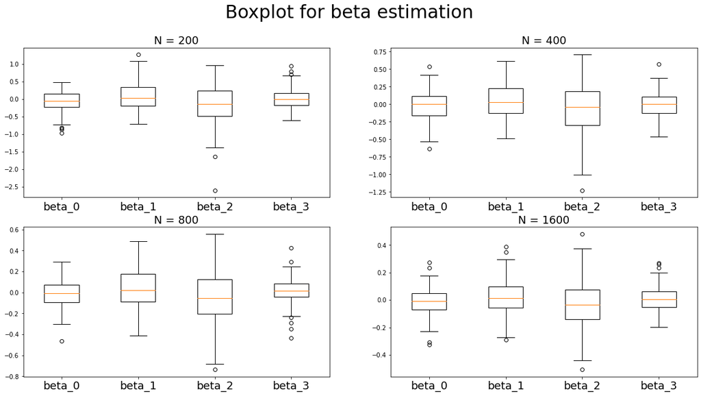

```python
# 计算\hat{\beta_j} - \beta_j
data = [[b - config.beta for b in eb] for eb in estimated_beta]

plt.figure(figsize=(20,10))
plt.subplot(2, 2, 1)
plt.boxplot(np.array(data[0]))
plt.xticks([1, 2, 3, 4], ["beta_0", "beta_1", "beta_2", "beta_3"], fontsize=18)
plt.title("N = 200", fontsize=18)

plt.subplot(2, 2, 2)
plt.boxplot(np.array(data[1]))
plt.xticks([1, 2, 3, 4], ["beta_0", "beta_1", "beta_2", "beta_3"], fontsize=18)
plt.title("N = 400", fontsize=18)

plt.subplot(2, 2, 3)
plt.boxplot(np.array(data[2]))
plt.xticks([1, 2, 3, 4], ["beta_0", "beta_1", "beta_2", "beta_3"], fontsize=18)
plt.title("N = 800", fontsize=18)

plt.subplot(2, 2, 4)
plt.boxplot(np.array(data[3]))
plt.xticks([1, 2, 3, 4], ["beta_0", "beta_1", "beta_2", "beta_3"], fontsize=18)
plt.title("N = 1600", fontsize=18)

plt.suptitle("Boxplot for beta estimation", fontsize=30)
plt.show()
```

观察四个箱型图子图，尤其是它们的y轴范围，可见随着样本数的增多，估计参数的总体偏差逐渐向0靠近，在N=1600时所有参数的偏差最为接近0。

# Part2

互联网的出现和扩张，改变了人们的生活。其中之一，就是为术业有专攻的人们提供了发光发热的新方式。本案例将探索这股知识网红热潮中的一个分支，如何通过一对一聊天的方式来建立自己的职业声誉。我们选取了知识共享网站在行上的行家约聊数据，探索了行家受欢迎程度的分布特征和影响因素，并根据数据分析的结果为想要进入这个领域的专业人士提供了自我包装的建议。数据共分为四个文件，“D-cate.csv”为话题分类，“D-mentor.csv”为行家属性，“D-topic.csv”为话题属性、“D-comment.csv”为用户评价信息。由于变量较多，具体变量含义请参照“REDAME.txt”。

```python
from google.colab import drive
drive.mount("/content/drive")

import os
path="/content/drive/My Drive/Colab Notebooks/datamining_data"
os.chdir(path)
os.listdir(path)
```

```
['HW4-石霭青-21210980011.ipynb',
 'D-cate.csv',
 'D-comment.csv',
 'D-mentor.csv',
 'D-topic.csv',
 'README.txt']
```

```python
import pandas as pd
%load_ext rpy2.ipython
```

## 1 任务一：数据读入

- 读入所有话题的分类属性D-cate.csv，命名为cate
- 读入行家属性D-mentor.csv，命名为mentor
- 读入话题属性D-topic.csv，命名为topic
- 读入用户对话题做出的评价D-comment.csv，命名为comment

```python
cate = pd.read_csv('./D-cate.csv')
mentor = pd.read_csv('./D-mentor.csv')
topic = pd.read_csv('./D-topic.csv')
comment = pd.read_csv('./D-comment.csv')
```

```python
cate.describe()
```

|  | mentor_id | topic_id | mentor_ordcnt | heart |
| --- | --- | --- | --- | --- |
| count | 1.530800e+04 | 1.530800e+04 | 14367.000000 | 14367.000000 |
| mean | 8.490621e+07 | 2.987231e+07 | 37.112202 | 177.980859 |
| std | 1.532840e+05 | 6.882166e+03 | 83.069180 | 294.835183 |
| min | 8.474379e+07 | 2.985950e+07 | 0.000000 | 0.000000 |
| 25% | 8.477906e+07 | 2.986690e+07 | 4.000000 | 26.000000 |
| 50% | 8.484169e+07 | 2.987264e+07 | 12.000000 | 78.000000 |
| 75% | 8.502316e+07 | 2.987850e+07 | 36.000000 | 203.000000 |
| max | 8.531929e+07 | 2.988334e+07 | 1493.000000 | 5796.000000 |

```python
cate.info()
```

```
<class 'pandas.core.frame.DataFrame'>
RangeIndex: 15308 entries, 0 to 15307
Data columns (total 9 columns):
 #   Column         Non-Null Count  Dtype
---  ------         --------------  -----
 0   mentor_id      15308 non-null  int64
 1   mentor_name    15308 non-null  object
 2   topic_id       15308 non-null  int64
 3   topic_name     15308 non-null  object
 4   topic_tag      15308 non-null  object
 5   mentor_ordcnt  14367 non-null  float64
 6   heart          14367 non-null  float64
 7   arating        11985 non-null  object
 8   mentor_city    14470 non-null  object
dtypes: float64(2), int64(2), object(5)
memory usage: 1.1+ MB
```

```python
mentor.describe()
```

|  | mentor_id | mentor_ordcnt | online_class | heart |
| --- | --- | --- | --- | --- |
| count | 7.943000e+03 | 7943.000000 | 7943.000000 | 7943.000000 |
| mean | 8.491319e+07 | 20.934911 | 1.054262 | 114.373285 |
| std | 1.514696e+05 | 54.306441 | 39.112114 | 210.541065 |
| min | 8.474379e+07 | 0.000000 | 0.000000 | 0.000000 |
| 25% | 8.478425e+07 | 2.000000 | 0.000000 | 17.000000 |
| 50% | 8.487704e+07 | 6.000000 | 0.000000 | 44.000000 |
| 75% | 8.503655e+07 | 19.000000 | 0.000000 | 123.000000 |
| max | 8.527710e+07 | 1493.000000 | 2996.000000 | 5796.000000 |

```python
mentor.info()
```

```
<class 'pandas.core.frame.DataFrame'>
RangeIndex: 7943 entries, 0 to 7942
Data columns (total 12 columns):
 #   Column           Non-Null Count  Dtype
---  ------           --------------  -----
 0   mentor_url       7943 non-null   object
 1   mentor_id        7943 non-null   int64
 2   mentor_name      7943 non-null   object
 3   mentor_identity  7943 non-null   object
 4   react_tm         7943 non-null   object
 5   mentor_ordcnt    7943 non-null   int64
 6   online_class     7943 non-null   int64
 7   heart            7943 non-null   int64
 8   arating          7943 non-null   object
 9   mentor_city      7943 non-null   object
 10  mentor_location  7942 non-null   object
 11  mentor_desc      7935 non-null   object
dtypes: int64(4), object(8)
memory usage: 744.8+ KB
```

```python
topic.describe()
```

|  | topic_id | mentor_id | price | disprice | score | topic_ordcnt |
| --- | --- | --- | --- | --- | --- | --- |
| count | 1.379700e+04 | 1.379700e+04 | 13797.000000 | 400.000000 | 7518.000000 | 13797.000000 |
| mean | 2.987188e+07 | 8.489887e+07 | 541.405016 | 199.402500 | 9.282416 | 10.677321 |
| std | 6.633186e+03 | 1.456961e+05 | 1834.113019 | 76.700377 | 0.298939 | 23.508287 |
| min | 2.985950e+07 | 8.474379e+07 | 1.000000 | 60.000000 | 7.000000 | 0.000000 |
| 25% | 2.986676e+07 | 8.477798e+07 | 300.000000 | 150.000000 | 9.200000 | 1.000000 |
| 50% | 2.987215e+07 | 8.483806e+07 | 499.000000 | 200.000000 | 9.300000 | 4.000000 |
| 75% | 2.987784e+07 | 8.500256e+07 | 521.000000 | 249.000000 | 9.500000 | 11.000000 |
| max | 2.988246e+07 | 8.527710e+07 | 200000.000000 | 500.000000 | 9.900000 | 687.000000 |

```python
topic.info()
```

```
<class 'pandas.core.frame.DataFrame'>
RangeIndex: 13797 entries, 0 to 13796
Data columns (total 13 columns):
 #   Column        Non-Null Count  Dtype
---  ------        --------------  -----
 0   topic_id      13797 non-null  int64
 1   topic_city    13797 non-null  object
 2   topic_url     13797 non-null  object
 3   mentor_id     13797 non-null  int64
 4   type          3319 non-null   object
 5   price         13797 non-null  int64
 6   disprice      400 non-null    float64
 7   score         7518 non-null   float64
 8   topic_name    13797 non-null  object
 9   duration      13797 non-null  object
 10  topic_ordcnt  13797 non-null  int64
 11  topic_tag     13797 non-null  object
 12  topic_desc    13797 non-null  object
dtypes: float64(2), int64(4), object(7)
memory usage: 1.4+ MB
```

```python
comment.describe()
```

|  | topic_id | comment_id | likings_count | score | reviews_count | duration_1 | user_id | user_industry_id | mentor_id | is_reply |
| --- | --- | --- | --- | --- | --- | --- | --- | --- | --- | --- |
| count | 1.076870e+05 | 107687.000000 | 107687.000000 | 107687.000000 | 107687.000000 | 107687.000000 | 1.076870e+05 | 70118.000000 | 1.076870e+05 | 107687.000000 |
| mean | 2.986913e+07 | 70152.267321 | 0.363015 | 8.865832 | 43.766351 | 80.738501 | 8.496707e+07 | 25.025956 | 8.485030e+07 | 0.242963 |
| std | 6.248793e+03 | 39467.110443 | 1.083708 | 2.018351 | 63.102911 | 28.535697 | 1.646728e+05 | 23.459198 | 1.166985e+05 | 0.428875 |
| min | 2.985950e+07 | 2.000000 | 0.000000 | 0.000000 | 1.000000 | 30.000000 | 8.474380e+07 | 2.000000 | 8.474379e+07 | 0.000000 |
| 25% | 2.986352e+07 | 35901.500000 | 0.000000 | 9.100000 | 9.000000 | 60.000000 | 8.481188e+07 | 2.000000 | 8.476608e+07 | 0.000000 |
| 50% | 2.986868e+07 | 71096.000000 | 0.000000 | 9.300000 | 21.000000 | 60.000000 | 8.492215e+07 | 15.000000 | 8.480002e+07 | 0.000000 |
| 75% | 2.987433e+07 | 105050.500000 | 0.000000 | 9.500000 | 48.000000 | 90.000000 | 8.511804e+07 | 49.000000 | 8.490302e+07 | 0.000000 |
| max | 2.988245e+07 | 135007.000000 | 71.000000 | 9.900000 | 378.000000 | 180.000000 | 8.527843e+07 | 63.000000 | 8.527316e+07 | 1.000000 |

```python
comment.info()
```

```
<class 'pandas.core.frame.DataFrame'>
RangeIndex: 107687 entries, 0 to 107686
Data columns (total 14 columns):
 #   Column              Non-Null Count   Dtype
---  ------              --------------   -----
 0   topic_id            107687 non-null  int64
 1   comment_id          107687 non-null  int64
 2   likings_count       107687 non-null  int64
 3   score               107687 non-null  float64
 4   reviews_count       107687 non-null  int64
 5   duration_1          107687 non-null  int64
 6   service_type        107687 non-null  object
 7   user_id             107687 non-null  int64
 8   user_city           83957 non-null   object
 9   user_is_tutor       107687 non-null  bool
 10  user_industry_id    70118 non-null   float64
 11  user_industry_name  70118 non-null   object
 12  mentor_id           107687 non-null  int64
 13  is_reply            107687 non-null  int64
dtypes: bool(1), float64(2), int64(8), object(3)
memory usage: 10.8+ MB
```

## 2 任务二：数据处理

### 2.1 类别变量处理

对mentor表中的行家接受率arating，设置高接受率、中接受率、其他共三个水平；对mentor表中的行家回应邀约时间react_tm，设置半天内回应、1天内回应、2天内回应、其他共四个水平；对topic表中的话题约见城市topic_city，设置北京、上海、深圳、广州、杭州、成都、武汉、西安、宁波、其他共10个水平。

```python
# 对mentor表中的行家接受率arating，设置高接受率、中接受率、其他共三个水平
print('原始行家接受率arating类别', mentor['arating'].unique())
print('其他行家接受率arating类别', mentor[(mentor['arating']!='高接受率') & (mentor['arating']!='中接受率')]['arating'].unique())
mentor.loc[(mentor['arating']!='高接受率') & (mentor['arating']!='中接受率'), 'arating'] = '其他'
print('处理后的行家接受率arating类别', mentor['arating'].unique())
```

```
原始行家接受率arating类别 ['缺失' '高接受率' '中接受率' '低接受率']
其他行家接受率arating类别 ['缺失' '低接受率']
处理后的行家接受率arating类别 ['其他' '高接受率' '中接受率']
```

```python
# 对mentor表中的行家回应邀约时间react_tm，设置半天内回应、1天内回应、2天内回应、其他共四个水平
print('原始行家回应邀约时间react_tm类别', mentor['react_tm'].unique())
```

```
原始行家回应邀约时间react_tm类别 ['半天内回应' '1天内回应' '其他' '2天内回应']
```

```python
# 对topic表中的话题约见城市topic_city，设置北京、上海、深圳、广州、杭州、成都、武汉、西安、宁波、其他共10个水平
print('原始话题约见城市topic_city类别', topic['topic_city'].unique())
```

```
原始话题约见城市topic_city类别 ['北京' '杭州' '上海' '广州' '深圳' '成都' '宁波' '西安' '武汉']
```

## 2.2 构造变量

在topic表中增加9个0-1变量：d1-d9，分别对应心理、投资理财、职场发展、教育学习、创业和融资、生活服务、互联网+、兴业经验、其他共9个话题；在topic中增加0-1变量：is_ord，话题是否成交（topic_ordcnt>0）；在topic中增加0-1变量：is_fst，话题是否发生在北上深；topic中增加话题价格带：price_b，分为<=300、(300,600]、(600,1000)、1000+四个水平；对price_b因子化，并设定各取值的顺序；topic表中增加话题描述长度：len_desc，话题描述字符数，划分为(0,200]、(200,400]、(400,600]、(600,800]、(800,1000]、1000+六个水平；topic表中增加行家是否回复用户评价：is_rpl，行家是否回复用户评价（聚合comment表中is_reply得到reply_cnt，reply_cnt>0）。

```python
# 在topic表中增加9个0-1变量：d1-d9，分别对应心理、投资理财、职场发展、教育学习、创业和融资、生活服务、互联网+、兴业经验、其他共9个话题
print('原始topic表中topic_tag类别: ', topic.topic_tag.unique())
topic['topic_tag_list'] = topic['topic_tag'].apply(lambda x: x.split('^'))
total_tag = []
for tt in topic['topic_tag_list']:
  total_tag.extend(tt)
print('unique topic_tag类别: ', set(total_tag))

topic.loc[:, 'd1'] = topic['topic_tag_list'].apply(lambda x: 1 if '心理' in x else 0)
topic.loc[:, 'd2'] = topic['topic_tag_list'].apply(lambda x: 1 if '投资理财' in x else 0)
topic.loc[:, 'd3'] = topic['topic_tag_list'].apply(lambda x: 1 if '职场发展' in x else 0)
topic.loc[:, 'd4'] = topic['topic_tag_list'].apply(lambda x: 1 if '教育学习' in x else 0)
topic.loc[:, 'd5'] = topic['topic_tag_list'].apply(lambda x: 1 if '创业和投融资' in x else 0)
topic.loc[:, 'd6'] = topic['topic_tag_list'].apply(lambda x: 1 if '生活服务' in x else 0)
topic.loc[:, 'd7'] = topic['topic_tag_list'].apply(lambda x: 1 if '互联网+' in x else 0)
topic.loc[:, 'd8'] = topic['topic_tag_list'].apply(lambda x: 1 if '行业经验' in x else 0)
topic.loc[:, 'd9'] = topic['topic_tag_list'].apply(lambda x: 1 if '其他' in x else 0)

topic = topic.drop(columns=['topic_tag_list'])
```

```
原始topic表中topic_tag类别:  ['生活服务' '互联网+' '创业和投融资' '职场发展^行业经验' '职场发展' '教育学习' '行业经验' '行业经验^互联网+'
 '投资理财' '其他' '心理^其他' '心理' '教育学习^其他' '职场发展^行业经验^互联网+' '职场发展^互联网+' '生活服务^心理'
 '生活服务^教育学习' '职场发展^生活服务' '生活服务^投资理财' '互联网+^创业和投融资' '心理^教育学习' '互联网+^生活服务'
 '行业经验^生活服务' '行业经验^创业和投融资' '行业经验^互联网+^创业和投融资' '职场发展^创业和投融资' '创业和投融资^生活服务'
 '职场发展^教育学习' '职场发展^行业经验^创业和投融资' '职场发展^其他' '行业经验^教育学习' '创业和投融资^教育学习'
 '职场发展^心理' '行业经验^其他' '投资理财^教育学习' '行业经验^投资理财' '行业经验^创业和投融资^生活服务' '生活服务^其他'
 '互联网+^其他' '职场发展^互联网+^生活服务' '职场发展^投资理财' '互联网+^教育学习' '行业经验^教育学习^其他'
 '行业经验^生活服务^其他' '创业和投融资^其他' '职场发展^教育学习^其他' '行业经验^生活服务^投资理财'
 '互联网+^创业和投融资^生活服务' '职场发展^行业经验^互联网+^生活服务' '职场发展^心理^教育学习' '生活服务^教育学习^其他'
 '行业经验^互联网+^生活服务' '职场发展^创业和投融资^生活服务' '互联网+^投资理财' '行业经验^互联网+^教育学习'
 '互联网+^创业和投融资^教育学习' '创业和投融资^心理' '行业经验^心理' '职场发展^行业经验^其他' '互联网+^心理']
unique topic_tag类别:  {'生活服务', '互联网+', '行业经验', '教育学习', '投资理财', '其他', '创业和投融资', '职场发展', '心理'}
```

```python
# 在topic中增加0-1变量：is_ord，话题是否成交（topic_ordcnt>0）
topic.loc[:, 'is_ord'] = topic['topic_ordcnt'].apply(lambda x: 1 if x > 0 else 0)
```

```python
# 在topic中增加0-1变量：is_fst，话题是否发生在北上深
print('原始topic表中topic_city类别: ', topic.topic_city.unique())
topic.loc[:, 'is_fst'] = topic['topic_city'].apply(lambda x: 1 if x in ['北京', '上海', '深圳'] else 0)
```

```
原始topic表中topic_city类别:  ['北京' '杭州' '上海' '广州' '深圳' '成都' '宁波' '西安' '武汉']
```

```python
# topic中增加话题价格带：price_b，分为<=300、(300,600]、(600,1000)、1000+四个水平
topic.loc[:, 'price_b'] = topic['price'].apply(lambda x: '<=300' if x <=300 else ('(300,600]' if x <= 600 else ('(600,1000)' if x < 1000 else '1000+')))
```

```python
# topic表中增加话题描述长度：len_desc，话题描述字符数，划分为(0,200]、(200,400]、(400,600]、(600,800]、(800,1000]、1000+六个水平
topic.loc[:, 'len_desc'] = topic['topic_desc'].apply(lambda x: '(0,200]' if len(x) <=200 else ('(200,400]' if len(x) <= 400 else ('(400,600]' if len(x) <= 600 else ('(600,800]' if len(x) <= 800 else ('(800,1000]' if len(x) <= 1000 else '1000+')))))
```

```python
# topic表中增加行家是否回复用户评价：is_rpl，行家是否回复用户评价（聚合comment表中is_reply得到reply_cnt，reply_cnt>0）
temp = pd.merge(topic[['topic_id']], comment[['topic_id', 'is_reply']], on='topic_id', how='left')
temp['is_reply'] = temp['is_reply'].fillna(0.0)
topic['is_rpl'] = list(temp.groupby('topic_id')['is_reply'].sum())
topic['is_rpl'] = topic['is_rpl'].apply(lambda x: 1 if x > 0 else 0)
```

### 2.3 因子型变量转换（R语言）

将以下变量转为R语言中的因子型：

mentor表中的行家接受率arating，mentor表中的行家回应邀约时间react_tm，topic表中的话题约见城市topic_city，topic表中的心理、投资理财、职场发展、教育学习、创业和融资、生活服务、互联网+、行业经验、其他共9个话题，topic中的0-1变量is_ord，topic中的0-1变量is_fst，topic中的话题价格带price_b（设定各取值的顺序），topic表中的话题描述长度len_desc（设定各取值的顺序），topic表中行家是否回复用户评价is_rpl

```python
%%R -i topic -i mentor
mentor$arating <- factor(mentor$arating, levels=c("其他", "中接受率", "高接受率"))
mentor$react_tm <- factor(mentor$react_tm, levels=c('2天内回应', '1天内回应', '半天内回应', '其他'))
topic$topic_city <- factor(topic$topic_city)
topic$d1 <- factor(topic$d1, levels=c(0, 1))
topic$d2 <- factor(topic$d2, levels=c(0, 1))
topic$d3 <- factor(topic$d3, levels=c(0, 1))
topic$d4 <- factor(topic$d4, levels=c(0, 1))
topic$d5 <- factor(topic$d5, levels=c(0, 1))
topic$d6 <- factor(topic$d6, levels=c(0, 1))
topic$d7 <- factor(topic$d7, levels=c(0, 1))
topic$d8 <- factor(topic$d8, levels=c(0, 1))
topic$d9 <- factor(topic$d9, levels=c(0, 1))
topic$is_ord <- factor(topic$is_ord, levels=c(0, 1))
topic$is_fst <- factor(topic$is_fst, levels=c(0, 1))
topic$price_b <- factor(topic$price_b, levels=c('<=300', '(300,600]', '(600,1000)', '1000+'))
topic$len_desc <- factor(topic$len_desc, levels=c('(0,200]', '(200,400]', '(400,600]', '(600,800]', '(800,1000]', '1000+'))
topic$is_rpl <- factor(topic$is_rpl, levels=c(0, 1))
```

## 3 任务三：绘制导师约见人数分布直方图

绘制导师约见人数分布直方图（可以考虑对mentor$mentor_ordcnt做对数变换），并进行描述分析

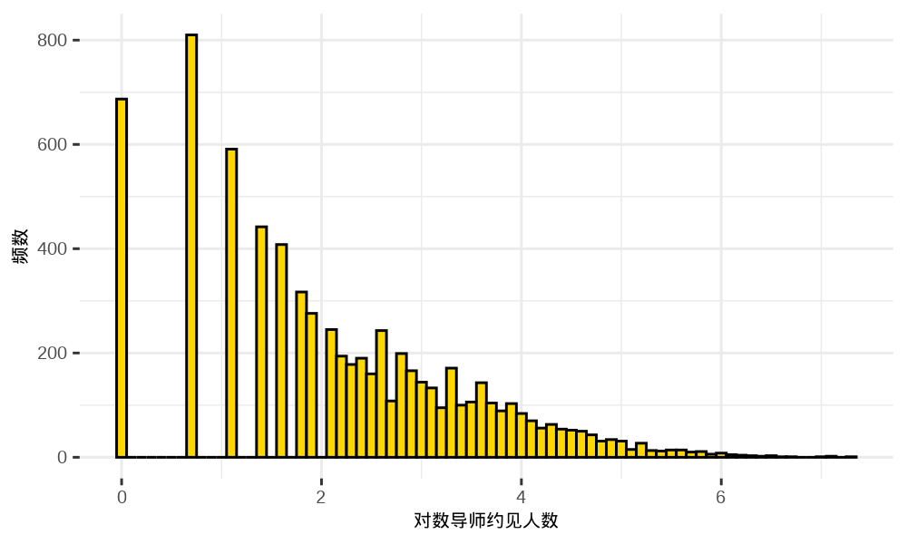

```python
%%R -w 5 -h 3 --units in -r 200
library(ggplot2)
chinese <- font_files()%>%
  as_tibble() %>%
  filter(str_detect(family, pattern = "^(FZ)|(Sim)|(ST)") |
           family == "WenQuanYi Micro Hei") %>%
  distinct() %>%
  mutate(path_file = paste0(path, "/", file))
map2(chinese$family, chinese$path_file, font_add)

mentor$log_mentor_ordcnt <- log(mentor$mentor_ordcnt)
ggplot(data = mentor,aes(x=log_mentor_ordcnt)) +
    geom_histogram(binwidth = 0.1,fill="gold", color="black") +
    labs(y="频数",x = "对数导师约见人数") +
    theme_bw() +
    theme(panel.border=element_blank(),
          axis.title = element_text(size = 15),
          axis.text = element_text(size = 15))
```

描述分析：可见导师约见人数呈现右偏分布，约见人数从少到多时，对应导师数目逐渐减少。

## 4 任务四：分领域（心理、投资理财等共9个领域）绘制行家约见人数（topic_ordcnt）的箱线图

分领域（心理、投资理财等共9个领域）绘制行家约见人数（topic_ordcnt）的箱线图，按中位数从左到右，从高到低的顺序排列，并进行描述分析

```python
temp = pd.merge(mentor[['mentor_id', 'mentor_ordcnt']], cate[['mentor_id', 'topic_tag']], how='left', on='mentor_id')
temp = temp.set_index(["mentor_id", "mentor_ordcnt"])["topic_tag"].str.split("^", expand=True).stack().reset_index(drop=True, level=-1).reset_index().rename(columns={0: "topic_tag"})
temp = temp.drop_duplicates()
temp.head(10)
```

|  | mentor_id | mentor_ordcnt | topic_tag |
| --- | --- | --- | --- |
| 0 | 85207405 | 3 | 职场发展 |
| 1 | 84914347 | 27 | 行业经验 |
| 2 | 84914347 | 27 | 职场发展 |
| 4 | 84795058 | 4 | 行业经验 |
| 5 | 84795058 | 4 | 互联网+ |
| 6 | 85049777 | 21 | 行业经验 |
| 7 | 85049777 | 21 | 互联网+ |
| 8 | 85049777 | 21 | 职场发展 |
| 13 | 84761583 | 4 | 投资理财 |
| 14 | 84897359 | 1 | 行业经验 |

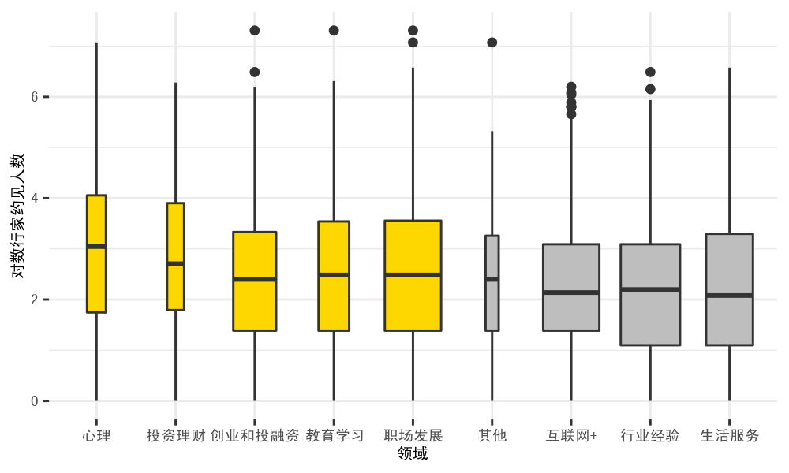

```python
%%R -i temp -w 5 -h 3 --units in -r 200
temp$topic_tag = factor(temp$topic_tag)
temp$log_mentor_ordcnt <- log(temp$mentor_ordcnt)

# 绘制箱线图(箱线图的箱子按中位数大小从左到右，从高到低排列)
#par(mfrow=c(1,2))
ggplot(temp,aes(x=reorder(topic_tag, -mentor_ordcnt, FUN=median),y=log_mentor_ordcnt)) +
        geom_boxplot(varwidth = TRUE, fill = c(rep("gold",5), rep("grey",4))) +
        labs(x="领域", y = "对数行家约见人数")+
    theme_bw() +
    theme(panel.border=element_blank(),
          text = element_text(family = "SimHei"),
        axis.title = element_text(size = 15),
          axis.text = element_text(size = 14))
```

## 5 任务五：绘制不同邀约接受率（arating）、不同响应时长（react_tm）、是否回复评价（is_rpl）和话题约见人数（topic_ordcnt）的箱线图

绘制不同邀约接受率（arating）、不同响应时长（react_tm）、是否回复评价（is_rpl）和话题约见人数（topic_ordcnt）的箱线图，并进行描述分析

```python
temp = pd.merge(topic[['is_rpl', 'topic_ordcnt', 'mentor_id']], mentor[['arating', 'react_tm', 'mentor_id']], on='mentor_id', how='inner')
temp.head()
```

|  | is_rpl | topic_ordcnt | mentor_id | arating | react_tm |
| --- | --- | --- | --- | --- | --- |
| 0 | 0 | 5 | 84743795 | 中接受率 | 其他 |
| 1 | 0 | 0 | 84743795 | 中接受率 | 其他 |
| 2 | 0 | 87 | 84743796 | 中接受率 | 2天内回应 |
| 3 | 0 | 19 | 84743796 | 中接受率 | 2天内回应 |
| 4 | 0 | 46 | 84743825 | 高接受率 | 2天内回应 |

```python
%%R -i temp -w 5 -h 3 --units in -r 200
temp$is_rpl = factor(temp$is_rpl, levels=c(0, 1))
temp$arating = factor(temp$arating, levels=c("其他", "中接受率", "高接受率"))
temp$react_tm = factor(temp$react_tm, levels=c('2天内回应', '1天内回应', '半天内回应', '其他'))

temp$log_topic_ordcnt <- log(temp$topic_ordcnt)
```

### 5.1 不同邀约接受率（arating）和话题约见人数（topic_ordcnt）的箱线图

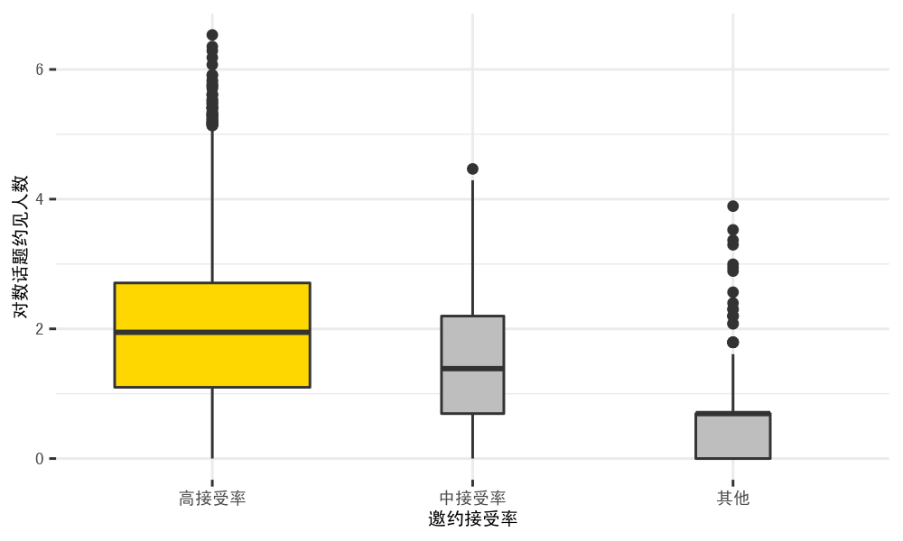

```python
%%R -w 5 -h 3 --units in -r 200
# 绘制箱线图(箱线图的箱子按中位数大小从左到右，从高到低排列)
#par(mfrow=c(1,2))
ggplot(temp,aes(x=reorder(arating, -topic_ordcnt, FUN=median),y=log_topic_ordcnt)) +
        geom_boxplot(varwidth = TRUE, fill = c(rep("gold",1), rep("grey",2))) +
        labs(x="邀约接受率", y = "对数话题约见人数")+
    theme_bw() +
    theme(panel.border=element_blank(),
          text = element_text(family = "SimHei"),
        axis.title = element_text(size = 15),
          axis.text = element_text(size = 14))
```

可见话题约见人数与对应导师（行家）的邀约接受率呈现正相关关系，高接收率导师对应的话题约见人数相应较多，较低接收率导师对应的话题约见人数相应较少。

### 5.2 不同响应时长（react_tm）和话题约见人数（topic_ordcnt）的箱线图

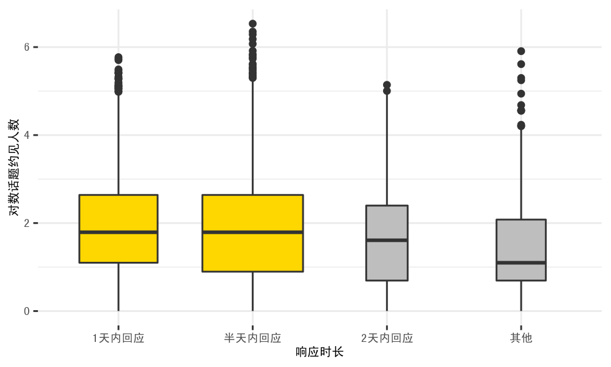

```python
%%R -w 5 -h 3 --units in -r 200
# 绘制箱线图(箱线图的箱子按中位数大小从左到右，从高到低排列)
#par(mfrow=c(1,2))
ggplot(temp,aes(x=reorder(react_tm, -topic_ordcnt, FUN=median),y=log_topic_ordcnt)) +
        geom_boxplot(varwidth = TRUE, fill = c(rep("gold",2), rep("grey",2))) +
        labs(x="响应时长", y = "对数话题约见人数")+
    theme_bw() +
    theme(panel.border=element_blank(),
          text = element_text(family = "SimHei"),
        axis.title = element_text(size = 15),
          axis.text = element_text(size = 14))
```

### 5.3 是否回复评价（is_rpl）和话题约见人数（topic_ordcnt）的箱线图

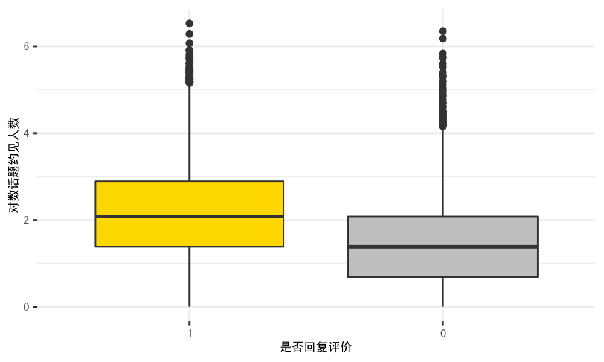

```python
%%R -w 5 -h 3 --units in -r 200
# 绘制箱线图(箱线图的箱子按中位数大小从左到右，从高到低排列)
#par(mfrow=c(1,2))
ggplot(temp,aes(x=reorder(is_rpl, -topic_ordcnt, FUN=median),y=log_topic_ordcnt)) +
        geom_boxplot(varwidth = TRUE, fill = c(rep("gold",1), rep("grey",1))) +
        labs(x="是否回复评价", y = "对数话题约见人数")+
    theme_bw() +
    theme(panel.border=element_blank(),
          text = element_text(family = "SimHei"),
        axis.title = element_text(size = 15),
          axis.text = element_text(size = 14))
```

可见，会回复用户评价的行家，对应的话题对数约见人数明显较多。

## 6 任务六：根据comment表中信息，绘制各行业用户数量柱状图并进行描述分析

```python
temp = comment[['user_id', 'user_industry_name']].dropna().drop_duplicates()
temp = pd.DataFrame(temp.groupby('user_industry_name')['user_id'].count()).reset_index()
temp.columns = ['user_industry_name', 'user_count']
```

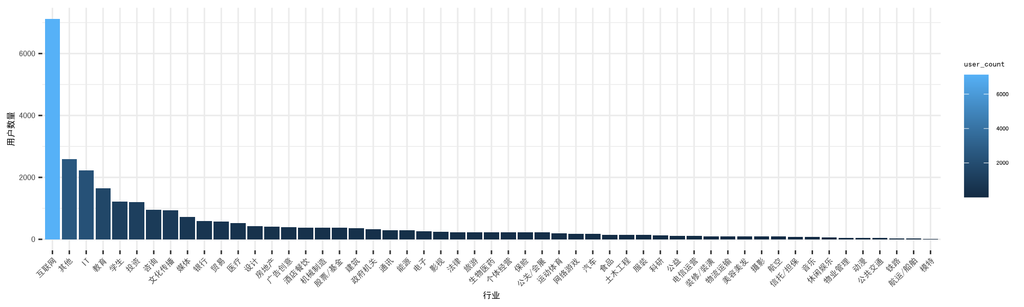

```python
%%R -i temp -w 10 -h 3 --units in -r 200

ggplot(temp, aes(x=reorder(user_industry_name, -user_count), y=user_count, fill=user_count)) + geom_col() +
    labs(x="行业", y="用户数量")+
    theme_bw() +
    theme(panel.border=element_blank(),
          text = element_text(family = "SimHei"),
          axis.title = element_text(size = 13),
          axis.text = element_text(size = 12),
          axis.text.x=element_text(angle=45, hjust=1))
```

描述分析：

- 互联网行业的用户数量最多，远超其他行业用户
- 除互联网外，其他、IT、教育、学生、投资、咨询、文化传播、媒体、银行、贸易、医疗等行业的用户数量也相对其他行业而言较多，这些行业也是我们平时能接触到的较为知识密集、活跃的行业
- 物业管理、动漫、公共交通、铁路、航运/船舶、模特等行业则较为小众，这也符合我们的常识

## 7 任务七：回归分析

```python
# 7 任务七：回归分析
# merge所需要的数据列
reg_data = topic[['is_ord', 'price', 'price_b', 'duration', 'topic_city', 'len_desc', 'is_fst', 'd1', 'd2', 'd3', 'd4', 'd5', 'd6', 'd7', 'd8', 'd9', 'mentor_id']]
reg_data = pd.merge(reg_data, mentor[['heart', 'mentor_ordcnt', 'react_tm', 'arating', 'mentor_id']], on='mentor_id', how='inner')
# 删除冗余列
reg_data = reg_data.drop(columns=['mentor_id']).drop_duplicates().reset_index(drop=True)
reg_data.head()
```

|  | is_ord | price | price_b | duration | topic_city | len_desc | is_fst | d1 | d2 | d3 | d4 | d5 | d6 | d7 | d8 | d9 | heart | mentor_ordcnt | react_tm | arating |
| --- | --- | --- | --- | --- | --- | --- | --- | --- | --- | --- | --- | --- | --- | --- | --- | --- | --- | --- | --- | --- |
| 0 | 1 | 400 | (300,600] | 1小时 | 北京 | (200,400] | 1 | 0 | 0 | 0 | 0 | 0 | 1 | 0 | 0 | 0 | 416 | 8 | 其他 | 中接受率 |
| 1 | 0 | 280 | <=300 | 2小时+ | 北京 | (200,400] | 1 | 0 | 0 | 0 | 0 | 0 | 1 | 0 | 0 | 0 | 416 | 8 | 其他 | 中接受率 |
| 2 | 1 | 1500 | 1000+ | 2小时 | 北京 | (600,800] | 1 | 0 | 0 | 0 | 0 | 0 | 1 | 0 | 0 | 0 | 990 | 106 | 2天内回应 | 中接受率 |
| 3 | 1 | 1200 | 1000+ | 2小时 | 北京 | (800,1000] | 1 | 0 | 0 | 0 | 0 | 0 | 1 | 0 | 0 | 0 | 990 | 106 | 2天内回应 | 中接受率 |
| 4 | 1 | 599 | (300,600] | 2小时 | 北京 | (600,800] | 1 | 0 | 0 | 0 | 0 | 0 | 0 | 1 | 0 | 0 | 559 | 81 | 2天内回应 | 高接受率 |

```python
%%R -i reg_data
# 将类别变量转成factor型
reg_data$is_ord <- factor(reg_data$is_ord, levels=c(0, 1))
reg_data$price_b <- factor(reg_data$price_b, levels=c('<=300', '(300,600]', '(600,1000)', '1000+'))
reg_data$duration <- factor(reg_data$duration)
reg_data$topic_city <- factor(reg_data$topic_city)
reg_data$len_desc <- factor(reg_data$len_desc, levels=c('(0,200]', '(200,400]', '(400,600]', '(600,800]', '(800,1000]', '1000+'))
reg_data$is_fst <- factor(reg_data$is_fst, levels=c(0, 1))
reg_data$d1 <- factor(reg_data$d1, levels=c(0, 1))
reg_data$d2 <- factor(reg_data$d2, levels=c(0, 1))
reg_data$d3 <- factor(reg_data$d3, levels=c(0, 1))
reg_data$d4 <- factor(reg_data$d4, levels=c(0, 1))
reg_data$d5 <- factor(reg_data$d5, levels=c(0, 1))
reg_data$d6 <- factor(reg_data$d6, levels=c(0, 1))
reg_data$d7 <- factor(reg_data$d7, levels=c(0, 1))
reg_data$d8 <- factor(reg_data$d8, levels=c(0, 1))
reg_data$d9 <- factor(reg_data$d9, levels=c(0, 1))
reg_data$react_tm <- factor(reg_data$react_tm, levels=c('2天内回应', '1天内回应', '半天内回应', '其他'))
reg_data$arating <- factor(reg_data$arating, levels=c("其他", "中接受率", "高接受率"))
```

```python
%%R
# 8:2划分训练集与测试集
library(caTools)
set.seed(32)
split = sample.split(reg_data$is_ord, SplitRatio = 0.8)

training_set = subset(reg_data, split == TRUE)
test_set = subset(reg_data, split == FALSE)
```

```python
%%R
# 逻辑回归
model.fit1 <- glm(formula = is_ord ~ ., family = binomial(), data = training_set)
summary(model.fit1)
```

```
Call:
glm(formula = is_ord ~ ., family = binomial(), data = training_set)

Deviance Residuals:
    Min       1Q   Median       3Q      Max
-3.2954   0.3067   0.4126   0.4908   1.4286

Coefficients: (1 not defined because of singularities)
                     Estimate Std. Error z value Pr(>|z|)
(Intercept)         3.997e-01  1.928e-01   2.074  0.03812 *
price              -1.062e-05  1.802e-05  -0.589  0.55565
price_b(300,600]    3.883e-02  6.611e-02   0.587  0.55697
price_b(600,1000)   3.309e-01  1.393e-01   2.376  0.01752 *
price_b1000+       -4.481e-02  1.594e-01  -0.281  0.77864
duration2小时      -2.150e-02  9.030e-02  -0.238  0.81186
duration2小时+      7.166e-02  6.538e-02   1.096  0.27308
topic_city北京      7.648e-02  7.863e-02   0.973  0.33070
topic_city宁波     -2.618e-01  2.824e-01  -0.927  0.35399
topic_city广州     -2.073e-02  1.353e-01  -0.153  0.87827
topic_city成都      1.296e-01  1.734e-01   0.748  0.45476
topic_city杭州      9.408e-02  1.468e-01   0.641  0.52161
topic_city武汉     -1.076e-01  1.964e-01  -0.548  0.58385
topic_city深圳      1.612e-03  1.122e-01   0.014  0.98854
topic_city西安      1.087e-01  2.070e-01   0.525  0.59964
len_desc(200,400]  -6.413e-02  1.077e-01  -0.596  0.55148
len_desc(400,600]   2.884e-02  1.143e-01   0.252  0.80076
len_desc(600,800]  -1.902e-01  1.339e-01  -1.420  0.15556
len_desc(800,1000] -9.893e-02  1.725e-01  -0.573  0.56635
len_desc1000+      -1.831e-01  1.847e-01  -0.992  0.32130
is_fst1                    NA         NA      NA       NA
d11                -1.159e-01  2.028e-01  -0.572  0.56762
d21                -2.922e-02  2.433e-01  -0.120  0.90442
d31                -1.290e-01  1.046e-01  -1.234  0.21735
d41                -7.778e-02  1.426e-01  -0.546  0.58534
d51                 1.304e-01  1.224e-01   1.065  0.28677
d61                -1.996e-01  1.142e-01  -1.748  0.08048 .
d71                 1.215e-01  9.710e-02   1.251  0.21091
d81                 2.076e-01  8.904e-02   2.331  0.01975 *
d91                -6.631e-02  2.982e-01  -0.222  0.82399
heart               8.607e-04  4.085e-04   2.107  0.03513 *
mentor_ordcnt       6.022e-03  1.987e-03   3.030  0.00245 **
react_tm1天内回应   1.116e-01  1.225e-01   0.911  0.36253
react_tm半天内回应 -5.090e-02  1.150e-01  -0.442  0.65813
react_tm其他       -5.810e-01  1.223e-01  -4.750 2.04e-06 ***
arating中接受率     1.507e+00  1.232e-01  12.229  < 2e-16 ***
arating高接受率     1.640e+00  7.112e-02  23.055  < 2e-16 ***
---
Signif. codes:  0 ‘***’ 0.001 ‘**’ 0.01 ‘*’ 0.05 ‘.’ 0.1 ‘ ’ 1

(Dispersion parameter for binomial family taken to be 1)

    Null deviance: 9116.3  on 10841  degrees of freedom
Residual deviance: 7682.6  on 10806  degrees of freedom
AIC: 7754.6

Number of Fisher Scoring iterations: 6
```

可见显著的变量较少，下面进一步做双向逐步回归，以AIC作为模型选择标准。

```python
%%R
model.aic <- step(model.fit1, direction = "both", trace = F)
summary(model.aic)
```

```
Call:
glm(formula = is_ord ~ price_b + d5 + d7 + d8 + heart + mentor_ordcnt +
    react_tm + arating, family = binomial(), data = training_set)

Deviance Residuals:
    Min       1Q   Median       3Q      Max
-3.2384   0.3099   0.4161   0.4888   1.3334

Coefficients:
                     Estimate Std. Error z value Pr(>|z|)
(Intercept)         0.2843876  0.1236673   2.300  0.02147 *
price_b(300,600]    0.0392819  0.0652089   0.602  0.54691
price_b(600,1000)   0.3211704  0.1379978   2.327  0.01995 *
price_b1000+       -0.0612883  0.1559793  -0.393  0.69437
d51                 0.2679095  0.0935493   2.864  0.00419 **
d71                 0.2192315  0.0715859   3.062  0.00219 **
d81                 0.2834273  0.0700401   4.047 5.20e-05 ***
heart               0.0008614  0.0004041   2.132  0.03302 *
mentor_ordcnt       0.0057836  0.0019510   2.964  0.00303 **
react_tm1天内回应   0.1148414  0.1221568   0.940  0.34716
react_tm半天内回应 -0.0553515  0.1146689  -0.483  0.62930
react_tm其他       -0.5826128  0.1219636  -4.777 1.78e-06 ***
arating中接受率     1.5044329  0.1225348  12.278  < 2e-16 ***
arating高接受率     1.6378623  0.0702995  23.298  < 2e-16 ***
---
Signif. codes:  0 ‘***’ 0.001 ‘**’ 0.01 ‘*’ 0.05 ‘.’ 0.1 ‘ ’ 1

(Dispersion parameter for binomial family taken to be 1)

    Null deviance: 9116.3  on 10841  degrees of freedom
Residual deviance: 7697.4  on 10828  degrees of freedom
AIC: 7725.4

Number of Fisher Scoring iterations: 6
```

回归结果分析：

- 可见经过模型选择后，剩下的自变量为price_b、d5、d7、d8、heart、mentor_ordcnt、react_tm、arating。其中系数显著的有price_b(600,1000)、d5、d7、d8、heart、mentor_ordcnt、react_tm其他、arating中接受率、arating高接受率。
- price_b(600,1000)系数显著为正，意味着价格在600-1000之间的话题更容易成交
- d5、d7、d8系数显著为正，意味着创业和投融资、互联网+、行业经验领域的话题更容易成交
- heart的系数显著为正，意味着相见行家的用户越多，行家对应的话题更容易成交
- mentor_ordcnt的系数显著为正，意味着行家过往约见人数越多，行家对应的话题更容易成交
- react_tm其他的系数显著为负，意味着行家回应邀约时间长于2天将使得话题更难成交
- arating中接受率、arating高接受率系数显著为正，意味着行家接受率较高时，行家对应的话题更容易成交

下面预测数据并绘制ROC曲线、计算AUC值

```
R[write to console]: Setting levels: control = 0, case = 1

R[write to console]: Setting direction: controls < cases
```

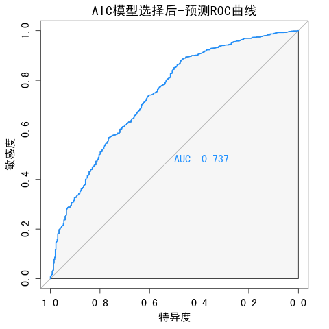

```python
%%R
library(pROC)
library(caret)
# 进行预测并绘制ROC曲线
pred <- predict(model.aic, test_set[, -grep("is_ord",colnames(test_set))], type="response")
roc_glm <- roc(test_set$is_ord, pred)
# 绘制ROC曲线
par(family='SimHei')
plot(roc_glm, col = "dodgerblue", print.auc=TRUE,
         auc.polygon=TRUE, auc.polygon.col="#f6f6f6", main = "AIC模型选择后-预测ROC曲线", xlim = c(1,0),
     xlab = "特异度",ylab = "敏感度")
```

根据曲线的结果，AUC值（即ROC曲线下的面积）为0.737，说明AIC选择后的模型对数据的预测效果较好。

下面打印混淆矩阵、ACC、p-value等

```python
%%R
## 打印混淆矩阵
#convert defaults from "Yes" and "No" to 1's and 0's
# descriptive_test$offertype_1 <- ifelse(as.logical(descriptive_test$offertype), 1, 0) %>% as.factor()
pred <- ifelse(pred > 0.5, 1, 0)  %>% as.factor()
confusionMatrix(test_set$is_ord, pred)  # 混淆矩阵
```

```
Confusion Matrix and Statistics

          Reference
Prediction    0    1
         0   58  345
         1   49 2258

               Accuracy : 0.8546
                 95% CI : (0.8408, 0.8677)
    No Information Rate : 0.9605
    P-Value [Acc > NIR] : 1

                  Kappa : 0.176

 Mcnemar's Test P-Value : <2e-16

            Sensitivity : 0.54206
            Specificity : 0.86746
         Pos Pred Value : 0.14392
         Neg Pred Value : 0.97876
             Prevalence : 0.03948
         Detection Rate : 0.02140
   Detection Prevalence : 0.14871
      Balanced Accuracy : 0.70476

       'Positive' Class : 0
```